# Practical Application III: Comparing Classifiers

**Overview**: In this practical application, your goal is to compare the performance of the classifiers we encountered in this section, namely K Nearest Neighbor, Logistic Regression, Decision Trees, and Support Vector Machines. We will utilize a dataset related to marketing bank products over the telephone.

### Getting Started

Our dataset comes from the UCI Machine Learning repository [link](https://archive.ics.uci.edu/ml/datasets/bank+marketing). The data is from a Portugese banking institution and is a collection of the results of multiple marketing campaigns. We will make use of the article accompanying the dataset here for more information on the data and features.

### Problem 1: Understanding the Data

To gain a better understanding of the data, please read the information provided in the UCI link above, and examine the **Materials and Methods** section of the paper. How many marketing campaigns does this data represent?

```python
# Data processing
import pandas as pd
import numpy as np

# Standardize the data
from sklearn.preprocessing import StandardScaler

# Modeling the data
from sklearn.model_selection import train_test_split
from sklearn.svm import SVC
from sklearn.ensemble import RandomForestClassifier
from sklearn.linear_model import LogisticRegression
from sklearn.tree import DecisionTreeClassifier

# Hyperparameter tuning
from sklearn.model_selection import GridSearchCV, RandomizedSearchCV, cross_val_score, StratifiedKFold

# Pre-processing
from sklearn.preprocessing import OneHotEncoder, FunctionTransformer
from sklearn.decomposition import PCA
from sklearn.compose import ColumnTransformer
from sklearn.neighbors import KNeighborsClassifier

# Oversampling Methods
from imblearn.over_sampling import SMOTE

# Plotting
import matplotlib.pyplot as plt
import scipy.stats as stats
import seaborn as sns

# Metrics and scoring: quantifying the quality of predictions
from sklearn.metrics import mean_squared_error, mean_absolute_error, classification_report, confusion_matrix
```

```python
# Default setting for plotting and pandas
%matplotlib inline

sns.set(style="darkgrid")
pd.set_option('display.max_rows', None)
pd.set_option('display.max_columns', None)
```

### Problem 2: Read in the Data

Use pandas to read in the dataset `bank-additional-full.csv` and assign to a meaningful variable name.

```python
banking_full_df = pd.read_csv('data/bank-additional-full.csv', sep = ';')
```

Let's see the sample dataset

```python
banking_full_df.head()
```

|  | age | job | marital | education | default | housing | loan | contact | month | day_of_week | duration | campaign | pdays | previous | poutcome | emp.var.rate | cons.price.idx | cons.conf.idx | euribor3m | nr.employed | y |
| --- | --- | --- | --- | --- | --- | --- | --- | --- | --- | --- | --- | --- | --- | --- | --- | --- | --- | --- | --- | --- | --- |
| 0 | 56 | housemaid | married | basic.4y | no | no | no | telephone | may | mon | 261 | 1 | 999 | 0 | nonexistent | 1.1 | 93.994 | -36.4 | 4.857 | 5191.0 | no |
| 1 | 57 | services | married | high.school | unknown | no | no | telephone | may | mon | 149 | 1 | 999 | 0 | nonexistent | 1.1 | 93.994 | -36.4 | 4.857 | 5191.0 | no |
| 2 | 37 | services | married | high.school | no | yes | no | telephone | may | mon | 226 | 1 | 999 | 0 | nonexistent | 1.1 | 93.994 | -36.4 | 4.857 | 5191.0 | no |
| 3 | 40 | admin. | married | basic.6y | no | no | no | telephone | may | mon | 151 | 1 | 999 | 0 | nonexistent | 1.1 | 93.994 | -36.4 | 4.857 | 5191.0 | no |
| 4 | 56 | services | married | high.school | no | no | yes | telephone | may | mon | 307 | 1 | 999 | 0 | nonexistent | 1.1 | 93.994 | -36.4 | 4.857 | 5191.0 | no |

### Problem 3: Understanding the Features

Examine the data description below, and determine if any of the features are missing values or need to be coerced to a different data type.

```
Input variables:
# bank client data:
1 - age (numeric)
2 - job : type of job (categorical: 'admin.','blue-collar','entrepreneur','housemaid','management','retired','self-employed','services','student','technician','unemployed','unknown')
3 - marital : marital status (categorical: 'divorced','married','single','unknown'; note: 'divorced' means divorced or widowed)
4 - education (categorical: 'basic.4y','basic.6y','basic.9y','high.school','illiterate','professional.course','university.degree','unknown')
5 - default: has credit in default? (categorical: 'no','yes','unknown')
6 - housing: has housing loan? (categorical: 'no','yes','unknown')
7 - loan: has personal loan? (categorical: 'no','yes','unknown')
# related with the last contact of the current campaign:
8 - contact: contact communication type (categorical: 'cellular','telephone')
9 - month: last contact month of year (categorical: 'jan', 'feb', 'mar', ..., 'nov', 'dec')
10 - day_of_week: last contact day of the week (categorical: 'mon','tue','wed','thu','fri')
11 - duration: last contact duration, in seconds (numeric). Important note: this attribute highly affects the output target (e.g., if duration=0 then y='no'). Yet, the duration is not known before a call is performed. Also, after the end of the call y is obviously known. Thus, this input should only be included for benchmark purposes and should be discarded if the intention is to have a realistic predictive model.
# other attributes:
12 - campaign: number of contacts performed during this campaign and for this client (numeric, includes last contact)
13 - pdays: number of days that passed by after the client was last contacted from a previous campaign (numeric; 999 means client was not previously contacted)
14 - previous: number of contacts performed before this campaign and for this client (numeric)
15 - poutcome: outcome of the previous marketing campaign (categorical: 'failure','nonexistent','success')
# social and economic context attributes
16 - emp.var.rate: employment variation rate - quarterly indicator (numeric)
17 - cons.price.idx: consumer price index - monthly indicator (numeric)
18 - cons.conf.idx: consumer confidence index - monthly indicator (numeric)
19 - euribor3m: euribor 3 month rate - daily indicator (numeric)
20 - nr.employed: number of employees - quarterly indicator (numeric)

Output variable (desired target):
21 - y - has the client subscribed a term deposit? (binary: 'yes','no')
```

### General Outline of EDA

- Preview data
- Check for total number of entries in columns and column data types
- Understand null percent in columns
- Check for any duplicate entries
- Plot count distribution of categorical data
- Plot distribution of numeric data (both univariate and pairwise joint distribution)
- are there any outliers. How to deal with outliers
- Is the data skewed? How to deal with skewed data

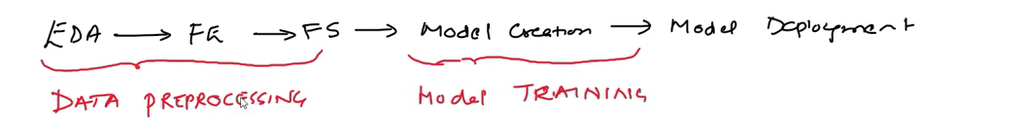

### Helper functions for performing EDA

```python
def get_null_percentage(df):
    return df.isnull().sum()*100/df.shape[0]

def remove_outliers(df, lower_value, upper_value, col_name):
    intial_num_rows = df.shape[0]
    df = df[(df[col_name] >= lower_value) & (df[col_name] <= upper_value)]
    print(f"percent of records with {col_name} outliers eliminated {(intial_num_rows - df.shape[0])*100/intial_num_rows}")
    return df

def drop_columns(df, cols_to_drop):
    df.drop(columns=cols_to_drop, inplace=True)
    return df

def get_value_counts_on_col(df, col):
    return df[col].value_counts()

def get_nunique_count(df, col=None):
    if not col:
        return df.nunique()
    else:
        return df[col].nunique()

def get_columns(df):
    return list(df.columns)

def count_plot(df, column, title, user_friendly_title):
    plt.figure(figsize=[6, 3])
    sns.countplot(data = df, y = column, order=df[column].value_counts().index)
    plt.title(title)
    plt.ylabel(user_friendly_title)
    plt.plot()

def get_cols_by_datatype(df, dtypes):
    cols_by_dtypes = df.columns.to_series().groupby(df.dtypes).groups
    if not dtypes:
        return cols_by_dtypes
    else:
        return {str(dtype): list(v) for dtype, v in cols_by_dtypes.items() if dtype in dtypes}

def visualize_outliers(df, col):
    fig, axis = plt.subplots(nrows=1, ncols=3, figsize=[12, 4])
    fig.suptitle(col)
    axis[0].boxplot(df[col])
    axis[1].hist(df[col])
    stats.probplot(df[col], plot=axis[2], dist="norm")
    plt.show()
```

```python
banking_full_df.describe(include='all')
```

|  | age | job | marital | education | default | housing | loan | contact | month | day_of_week | duration | campaign | pdays | previous | poutcome | emp.var.rate | cons.price.idx | cons.conf.idx | euribor3m | nr.employed | y |
| --- | --- | --- | --- | --- | --- | --- | --- | --- | --- | --- | --- | --- | --- | --- | --- | --- | --- | --- | --- | --- | --- |
| count | 41188.00000 | 41188 | 41188 | 41188 | 41188 | 41188 | 41188 | 41188 | 41188 | 41188 | 41188.000000 | 41188.000000 | 41188.000000 | 41188.000000 | 41188 | 41188.000000 | 41188.000000 | 41188.000000 | 41188.000000 | 41188.000000 | 41188 |
| unique | NaN | 12 | 4 | 8 | 3 | 3 | 3 | 2 | 10 | 5 | NaN | NaN | NaN | NaN | 3 | NaN | NaN | NaN | NaN | NaN | 2 |
| top | NaN | admin. | married | university.degree | no | yes | no | cellular | may | thu | NaN | NaN | NaN | NaN | nonexistent | NaN | NaN | NaN | NaN | NaN | no |
| freq | NaN | 10422 | 24928 | 12168 | 32588 | 21576 | 33950 | 26144 | 13769 | 8623 | NaN | NaN | NaN | NaN | 35563 | NaN | NaN | NaN | NaN | NaN | 36548 |
| mean | 40.02406 | NaN | NaN | NaN | NaN | NaN | NaN | NaN | NaN | NaN | 258.285010 | 2.567593 | 962.475454 | 0.172963 | NaN | 0.081886 | 93.575664 | -40.502600 | 3.621291 | 5167.035911 | NaN |
| std | 10.42125 | NaN | NaN | NaN | NaN | NaN | NaN | NaN | NaN | NaN | 259.279249 | 2.770014 | 186.910907 | 0.494901 | NaN | 1.570960 | 0.578840 | 4.628198 | 1.734447 | 72.251528 | NaN |
| min | 17.00000 | NaN | NaN | NaN | NaN | NaN | NaN | NaN | NaN | NaN | 0.000000 | 1.000000 | 0.000000 | 0.000000 | NaN | -3.400000 | 92.201000 | -50.800000 | 0.634000 | 4963.600000 | NaN |
| 25% | 32.00000 | NaN | NaN | NaN | NaN | NaN | NaN | NaN | NaN | NaN | 102.000000 | 1.000000 | 999.000000 | 0.000000 | NaN | -1.800000 | 93.075000 | -42.700000 | 1.344000 | 5099.100000 | NaN |
| 50% | 38.00000 | NaN | NaN | NaN | NaN | NaN | NaN | NaN | NaN | NaN | 180.000000 | 2.000000 | 999.000000 | 0.000000 | NaN | 1.100000 | 93.749000 | -41.800000 | 4.857000 | 5191.000000 | NaN |
| 75% | 47.00000 | NaN | NaN | NaN | NaN | NaN | NaN | NaN | NaN | NaN | 319.000000 | 3.000000 | 999.000000 | 0.000000 | NaN | 1.400000 | 93.994000 | -36.400000 | 4.961000 | 5228.100000 | NaN |
| max | 98.00000 | NaN | NaN | NaN | NaN | NaN | NaN | NaN | NaN | NaN | 4918.000000 | 56.000000 | 999.000000 | 7.000000 | NaN | 1.400000 | 94.767000 | -26.900000 | 5.045000 | 5228.100000 | NaN |

Get list of columns by datatype

```python
dict(banking_full_df.columns.to_series().groupby(banking_full_df.dtypes).groups)
```

```
{dtype('int64'): Index(['age', 'duration', 'campaign', 'pdays', 'previous'], dtype='object'),
 dtype('float64'): Index(['emp.var.rate', 'cons.price.idx', 'cons.conf.idx', 'euribor3m',
        'nr.employed'],
       dtype='object'),
 dtype('O'): Index(['job', 'marital', 'education', 'default', 'housing', 'loan', 'contact',
        'month', 'day_of_week', 'poutcome', 'y'],
       dtype='object')}
```

```python
# get number of rows and columns in the original dataset
orig_rows, orig_cols = banking_full_df.shape
print(f"Number of rows and columns in the original dataset: Rows: {orig_rows}  Columns: {orig_cols}")
```

```
Number of rows and columns in the original dataset: Rows: 41188  Columns: 21
```

```python
banking_full_df.info()
```

```
<class 'pandas.core.frame.DataFrame'>
RangeIndex: 41188 entries, 0 to 41187
Data columns (total 21 columns):
 #   Column          Non-Null Count  Dtype
---  ------          --------------  -----
 0   age             41188 non-null  int64
 1   job             41188 non-null  object
 2   marital         41188 non-null  object
 3   education       41188 non-null  object
 4   default         41188 non-null  object
 5   housing         41188 non-null  object
 6   loan            41188 non-null  object
 7   contact         41188 non-null  object
 8   month           41188 non-null  object
 9   day_of_week     41188 non-null  object
 10  duration        41188 non-null  int64
 11  campaign        41188 non-null  int64
 12  pdays           41188 non-null  int64
 13  previous        41188 non-null  int64
 14  poutcome        41188 non-null  object
 15  emp.var.rate    41188 non-null  float64
 16  cons.price.idx  41188 non-null  float64
 17  cons.conf.idx   41188 non-null  float64
 18  euribor3m       41188 non-null  float64
 19  nr.employed     41188 non-null  float64
 20  y               41188 non-null  object
dtypes: float64(5), int64(5), object(11)
memory usage: 6.6+ MB
```

```python
# duration: last contact duration, in seconds (numeric).
# Important note: this attribute highly affects the output target (e.g., if duration=0 then y='no').
# Yet, the duration is not known before a call is performed. Also, after the end of the call y is obviously known.
# Thus, this input should only be included for benchmark purposes and should be discarded if the
# intention is to have a realistic predictive model.
# other attributes:
banking_full_df.drop(columns=["duration"], inplace=True)
```

```python
print(f"Are there any duplicate rows in the dataset: {banking_full_df.duplicated().any()}")
print(f"Number of rows in the original dataset: {orig_rows}")
```

```
Are there any duplicate rows in the dataset: True
Number of rows in the original dataset: 41188
```

```python
banking_full_df.drop_duplicates(inplace=True)
```

```python
print(f"Are there any duplicate rows in the dataset after duplicate removal?: {banking_full_df.duplicated().any()}")
print(f"Number of duplicate records deleted: {orig_rows- banking_full_df.shape[0]}")
```

```
Are there any duplicate rows in the dataset after duplicate removal?: False
Number of duplicate records deleted: 1784
```

```python
# are there nulls values in data? Get null percentage by column
get_null_percentage(banking_full_df)
```

```
age               0.0
job               0.0
marital           0.0
education         0.0
default           0.0
housing           0.0
loan              0.0
contact           0.0
month             0.0
day_of_week       0.0
campaign          0.0
pdays             0.0
previous          0.0
poutcome          0.0
emp.var.rate      0.0
cons.price.idx    0.0
cons.conf.idx     0.0
euribor3m         0.0
nr.employed       0.0
y                 0.0
dtype: float64
```

```python
# Get count of unique values in the dataframe
get_nunique_count(banking_full_df)
```

```
age                78
job                12
marital             4
education           8
default             3
housing             3
loan                3
contact             2
month              10
day_of_week         5
campaign           42
pdays              27
previous            8
poutcome            3
emp.var.rate       10
cons.price.idx     26
cons.conf.idx      26
euribor3m         316
nr.employed        11
y                   2
dtype: int64
```

There are few categorical columns per nunique output above. Let's draw count plot

```python
# categorical columns and asscoiated metadata

categorical_columns = [{
    "col_name": "job",
    "col_user_friendly_name": "Job",
    "plot_title": "Job Distribution Plot",
},{
    "col_name": "marital",
    "col_user_friendly_name": "Marital",
    "plot_title": "Marital Distribution Plot",
},{
    "col_name": "education",
    "col_user_friendly_name": "Education",
    "plot_title": "Education Distribution Plot",
},{
    "col_name": "default",
    "col_user_friendly_name": "Default",
    "plot_title": "Default Distribution Plot",
},{
    "col_name": "housing",
    "col_user_friendly_name": "Housing",
    "plot_title": "Housing Loan Distribution Plot",
},{
    "col_name": "loan",
    "col_user_friendly_name": "Loan",
    "plot_title": "Loan Distribution Plot",
},{
    "col_name": "contact",
    "col_user_friendly_name": "Contact",
    "plot_title": "Contact Distribution Plot",
},{
    "col_name": "month",
    "col_user_friendly_name": "Month",
    "plot_title": "Month Distribution Plot",
},{
    "col_name": "day_of_week",
    "col_user_friendly_name": "Day of Week",
    "plot_title": "Day of Week Distribution Plot",
},{
    "col_name": "poutcome",
    "col_user_friendly_name": "Marketing Outcome",
    "plot_title": "Previous Marking Campaign outcome Distribution Plot",
},

]
```

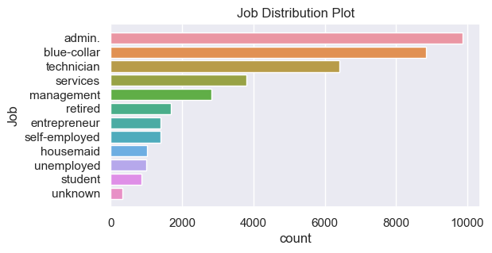

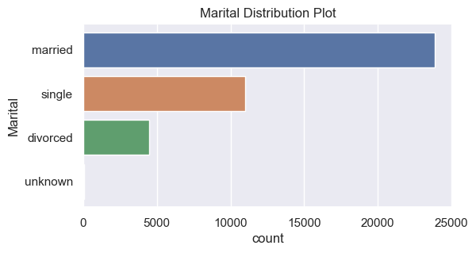

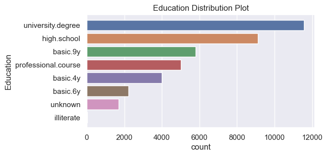

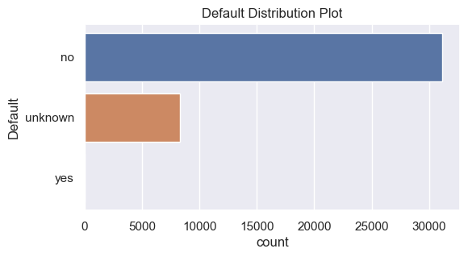

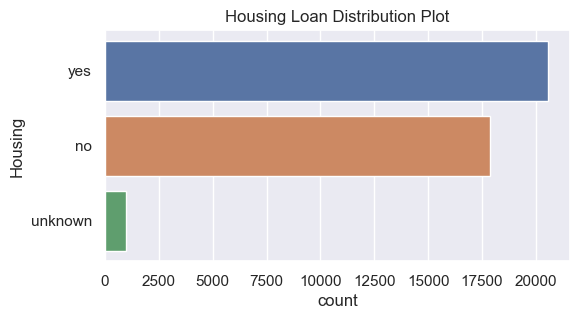

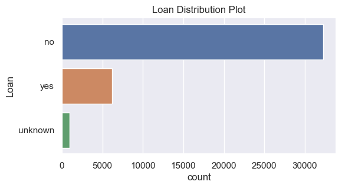

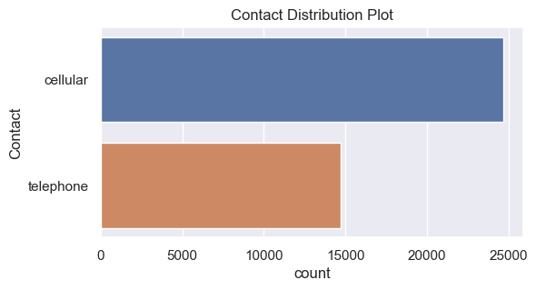

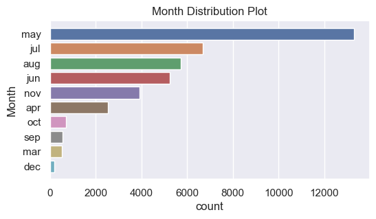

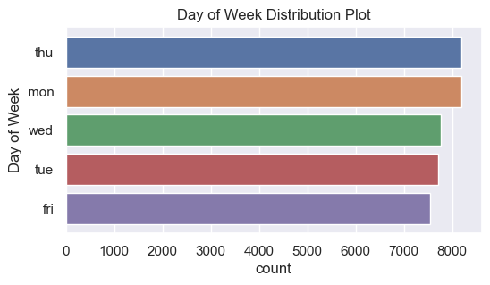

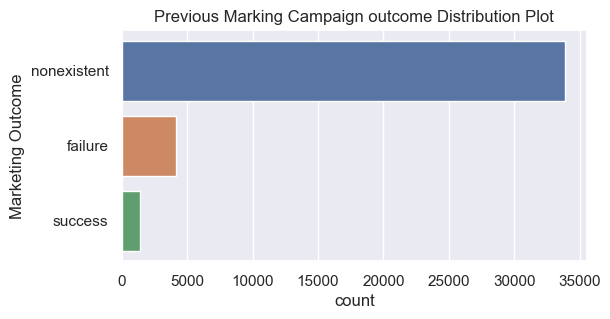

```python
for col_dict in categorical_columns:
    count_plot(banking_full_df,
               column=col_dict["col_name"],
               title=col_dict["plot_title"],
               user_friendly_title=col_dict["col_user_friendly_name"]
              )
```

```python
dups = banking_full_df.duplicated()
print('are there any duplicates? : ', dups.any())
```

```
are there any duplicates? :  False
```

```python
banking_full_df.columns.to_series().groupby(banking_full_df.dtypes).groups
```

```
{int64: ['age', 'campaign', 'pdays', 'previous'], float64: ['emp.var.rate', 'cons.price.idx', 'cons.conf.idx', 'euribor3m', 'nr.employed'], object: ['job', 'marital', 'education', 'default', 'housing', 'loan', 'contact', 'month', 'day_of_week', 'poutcome', 'y']}
```

### Plot distribution of numeric data (both univariate and pairwise joint distribution)

```python
numeric_col_dtypes = ["int64", "float64"]
cols_by_datatype = get_cols_by_datatype(df=banking_full_df, dtypes=numeric_col_dtypes)
cols_by_datatype
```

```
{'int64': ['age', 'campaign', 'pdays', 'previous'],
 'float64': ['emp.var.rate',
  'cons.price.idx',
  'cons.conf.idx',
  'euribor3m',
  'nr.employed']}
```

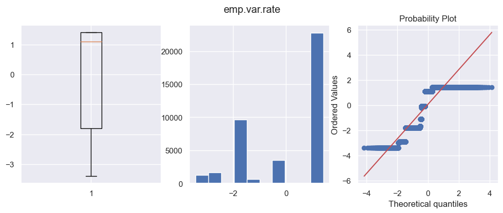

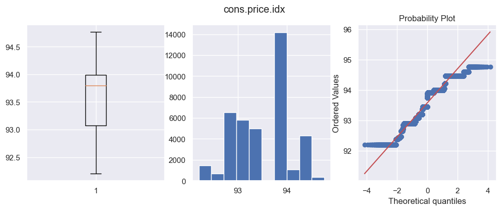

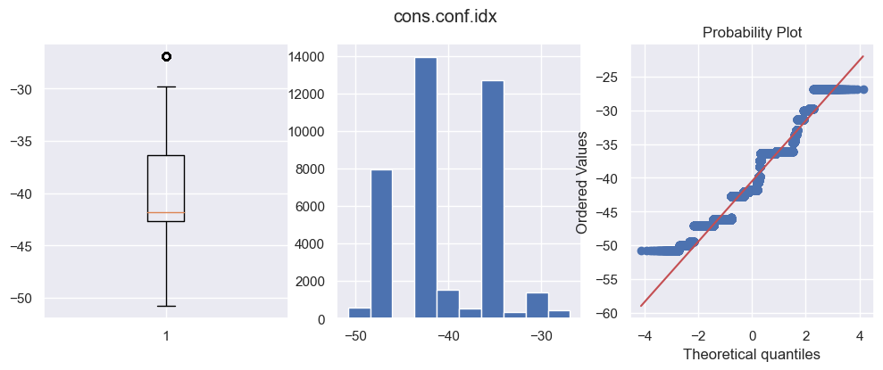

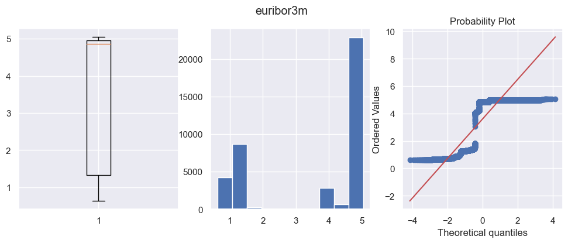

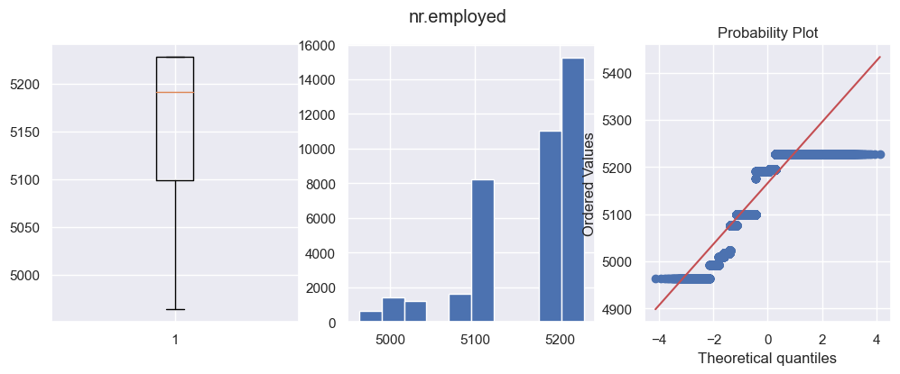

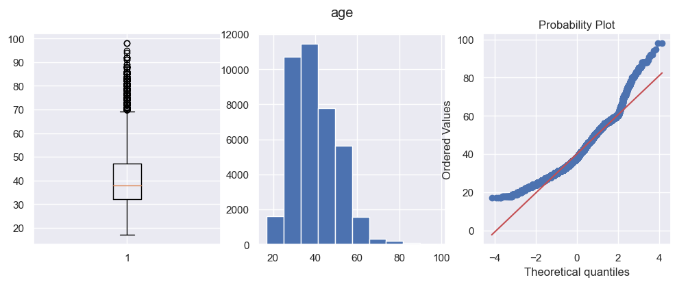

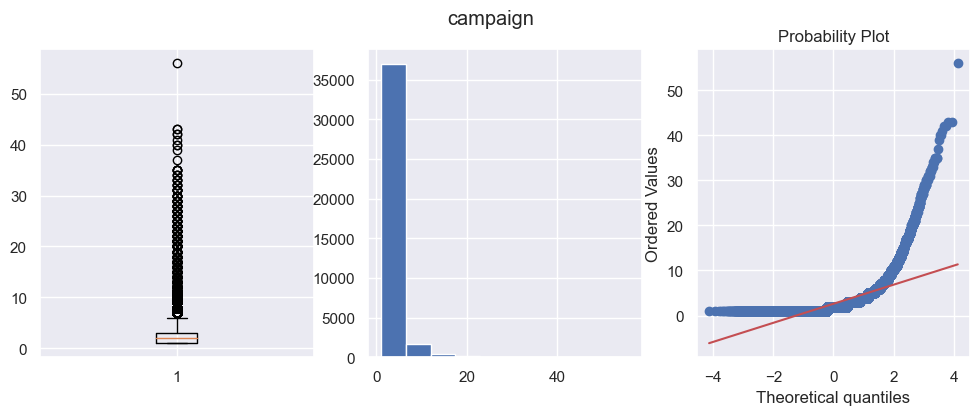

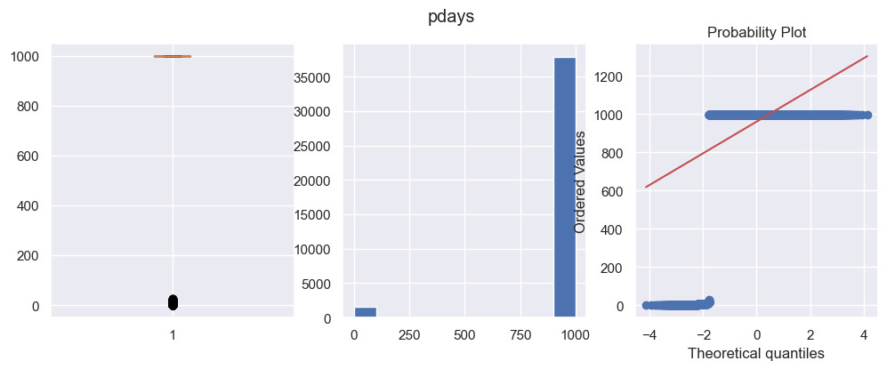

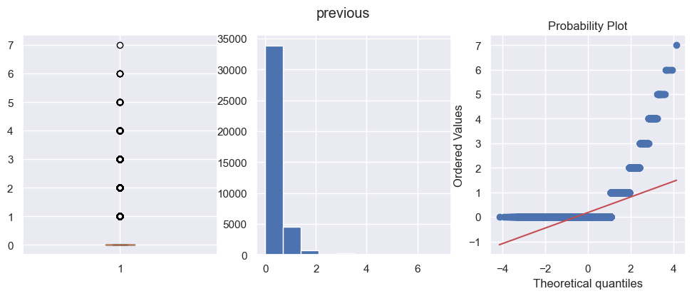

```python
# Plot box plot, probability plot and distribution plot for columns of numeric datatype.
cols = cols_by_datatype["float64"] + cols_by_datatype["int64"]
for col in cols:
    visualize_outliers(banking_full_df, col)
```

There are outliers in "cons.conf.idx" and "campaign" columns per above graph. Let's remove outliers and capture number of outlier datapoints removed.

```
Number of cons.conf.idx outlier rows removed: 436
Number of campaign outlier rows removed: 1
```

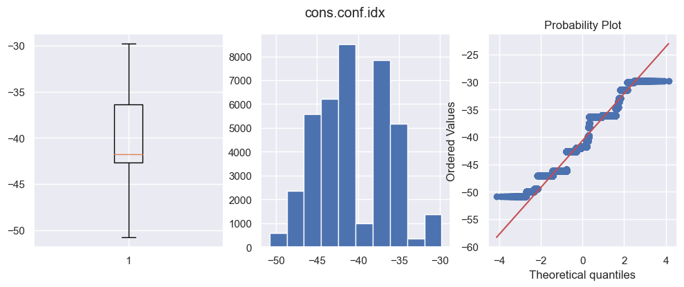

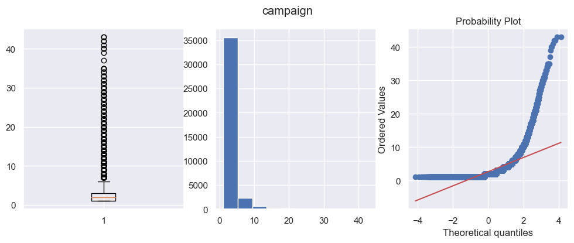

```python
# Per above plots, there are outliers in cons.conf.idx, campaign
outlier_cols = ["cons.conf.idx", "campaign"]

with_outlier_rows = banking_full_df.shape[0]
banking_full_df = banking_full_df[banking_full_df["cons.conf.idx"] < -28]
without_outlier_rows = banking_full_df.shape[0]
print (f"Number of cons.conf.idx outlier rows removed: {with_outlier_rows - without_outlier_rows}")

with_outlier_rows = banking_full_df.shape[0]
banking_full_df = banking_full_df[banking_full_df["campaign"] < 50]
without_outlier_rows = banking_full_df.shape[0]
print (f"Number of campaign outlier rows removed: {with_outlier_rows - without_outlier_rows}")

print("\n")

for col in outlier_cols:
    visualize_outliers(banking_full_df, col=col)
```

```python
# get unique count in each column of type Object
object_cols = get_cols_by_datatype(df=banking_full_df, dtypes=["object"])["object"]

banking_full_df[object_cols].nunique().sort_values(ascending=False)
```

```
job            12
month          10
education       8
day_of_week     5
marital         4
default         3
housing         3
loan            3
poutcome        3
contact         2
y               2
dtype: int64
```

```python
cleaned_data_before_encoding = banking_full_df.copy()
cleaned_data_before_encoding.head()
```

|  | age | job | marital | education | default | housing | loan | contact | month | day_of_week | campaign | pdays | previous | poutcome | emp.var.rate | cons.price.idx | cons.conf.idx | euribor3m | nr.employed | y |
| --- | --- | --- | --- | --- | --- | --- | --- | --- | --- | --- | --- | --- | --- | --- | --- | --- | --- | --- | --- | --- |
| 0 | 56 | housemaid | married | basic.4y | no | no | no | telephone | may | mon | 1 | 999 | 0 | nonexistent | 1.1 | 93.994 | -36.4 | 4.857 | 5191.0 | no |
| 1 | 57 | services | married | high.school | unknown | no | no | telephone | may | mon | 1 | 999 | 0 | nonexistent | 1.1 | 93.994 | -36.4 | 4.857 | 5191.0 | no |
| 2 | 37 | services | married | high.school | no | yes | no | telephone | may | mon | 1 | 999 | 0 | nonexistent | 1.1 | 93.994 | -36.4 | 4.857 | 5191.0 | no |
| 3 | 40 | admin. | married | basic.6y | no | no | no | telephone | may | mon | 1 | 999 | 0 | nonexistent | 1.1 | 93.994 | -36.4 | 4.857 | 5191.0 | no |
| 4 | 56 | services | married | high.school | no | no | yes | telephone | may | mon | 1 | 999 | 0 | nonexistent | 1.1 | 93.994 | -36.4 | 4.857 | 5191.0 | no |

Contact and y columns have 2 unique values. Let's use Label Encoding technique to encode values

```python
# contact has 2 unique values. Use label encoding
banking_full_df["contact"] = banking_full_df["contact"].astype("category").cat.codes
banking_full_df["y"] = banking_full_df["y"].astype("category").cat.codes
banking_full_df = banking_full_df.reset_index(drop=True)
```

```python
# Get columns eligible for encoding
cols_eligible_for_encoding = list(set(get_cols_by_datatype(df=banking_full_df,
                                                           dtypes=["object"])["object"]) - set(["y"]))

print(f"Columns eligible for encoding are: {', '.join(cols_eligible_for_encoding)}")
```

```
Columns eligible for encoding are: default, job, day_of_week, housing, poutcome, loan, education, month, marital
```

```python
# Encoding
encoder=OneHotEncoder(sparse=False)
df_encoded = pd.DataFrame(encoder.fit_transform(banking_full_df[cols_eligible_for_encoding]))

df_encoded.columns = encoder.get_feature_names_out(cols_eligible_for_encoding)

banking_full_df.drop(cols_eligible_for_encoding, axis=1, inplace=True)
banking_full_df= pd.concat([banking_full_df, df_encoded ], axis=1)
```

```python
banking_full_df.head()
```

|  | age | contact | campaign | pdays | previous | emp.var.rate | cons.price.idx | cons.conf.idx | euribor3m | nr.employed | y | default_no | default_unknown | default_yes | job_admin. | job_blue-collar | job_entrepreneur | job_housemaid | job_management | job_retired | job_self-employed | job_services | job_student | job_technician | job_unemployed | job_unknown | day_of_week_fri | day_of_week_mon | day_of_week_thu | … |
| --- | --- | --- | --- | --- | --- | --- | --- | --- | --- | --- | --- | --- | --- | --- | --- | --- | --- | --- | --- | --- | --- | --- | --- | --- | --- | --- | --- | --- | --- | --- |
| 0 | 56 | 1 | 1 | 999 | 0 | 1.1 | 93.994 | -36.4 | 4.857 | 5191.0 | 0 | 1.0 | 0.0 | 0.0 | 0.0 | 0.0 | 0.0 | 1.0 | 0.0 | 0.0 | 0.0 | 0.0 | 0.0 | 0.0 | 0.0 | 0.0 | 0.0 | 1.0 | 0.0 | … |
| 1 | 57 | 1 | 1 | 999 | 0 | 1.1 | 93.994 | -36.4 | 4.857 | 5191.0 | 0 | 0.0 | 1.0 | 0.0 | 0.0 | 0.0 | 0.0 | 0.0 | 0.0 | 0.0 | 0.0 | 1.0 | 0.0 | 0.0 | 0.0 | 0.0 | 0.0 | 1.0 | 0.0 | … |
| 2 | 37 | 1 | 1 | 999 | 0 | 1.1 | 93.994 | -36.4 | 4.857 | 5191.0 | 0 | 1.0 | 0.0 | 0.0 | 0.0 | 0.0 | 0.0 | 0.0 | 0.0 | 0.0 | 0.0 | 1.0 | 0.0 | 0.0 | 0.0 | 0.0 | 0.0 | 1.0 | 0.0 | … |
| 3 | 40 | 1 | 1 | 999 | 0 | 1.1 | 93.994 | -36.4 | 4.857 | 5191.0 | 0 | 1.0 | 0.0 | 0.0 | 1.0 | 0.0 | 0.0 | 0.0 | 0.0 | 0.0 | 0.0 | 0.0 | 0.0 | 0.0 | 0.0 | 0.0 | 0.0 | 1.0 | 0.0 | … |
| 4 | 56 | 1 | 1 | 999 | 0 | 1.1 | 93.994 | -36.4 | 4.857 | 5191.0 | 0 | 1.0 | 0.0 | 0.0 | 0.0 | 0.0 | 0.0 | 0.0 | 0.0 | 0.0 | 0.0 | 1.0 | 0.0 | 0.0 | 0.0 | 0.0 | 0.0 | 1.0 | 0.0 | … |

```python
contact_data = banking_full_df.drop(['contact'] ,axis=1, inplace=True)
banking_full_df = pd.concat([banking_full_df, contact_data ], axis=1)

cont_cols =  ['age', 'campaign', 'pdays', 'previous', 'emp.var.rate', 'cons.price.idx',
              'cons.conf.idx', 'euribor3m', 'nr.employed']

cont_indies = [banking_full_df.columns.get_loc(col) for col in cont_cols]
```

```python
banking_full_df.head(5)
```

|  | age | campaign | pdays | previous | emp.var.rate | cons.price.idx | cons.conf.idx | euribor3m | nr.employed | y | default_no | default_unknown | default_yes | job_admin. | job_blue-collar | job_entrepreneur | job_housemaid | job_management | job_retired | job_self-employed | job_services | job_student | job_technician | job_unemployed | job_unknown | day_of_week_fri | day_of_week_mon | day_of_week_thu | day_of_week_tue | … |
| --- | --- | --- | --- | --- | --- | --- | --- | --- | --- | --- | --- | --- | --- | --- | --- | --- | --- | --- | --- | --- | --- | --- | --- | --- | --- | --- | --- | --- | --- | --- |
| 0 | 56 | 1 | 999 | 0 | 1.1 | 93.994 | -36.4 | 4.857 | 5191.0 | 0 | 1.0 | 0.0 | 0.0 | 0.0 | 0.0 | 0.0 | 1.0 | 0.0 | 0.0 | 0.0 | 0.0 | 0.0 | 0.0 | 0.0 | 0.0 | 0.0 | 1.0 | 0.0 | 0.0 | … |
| 1 | 57 | 1 | 999 | 0 | 1.1 | 93.994 | -36.4 | 4.857 | 5191.0 | 0 | 0.0 | 1.0 | 0.0 | 0.0 | 0.0 | 0.0 | 0.0 | 0.0 | 0.0 | 0.0 | 1.0 | 0.0 | 0.0 | 0.0 | 0.0 | 0.0 | 1.0 | 0.0 | 0.0 | … |
| 2 | 37 | 1 | 999 | 0 | 1.1 | 93.994 | -36.4 | 4.857 | 5191.0 | 0 | 1.0 | 0.0 | 0.0 | 0.0 | 0.0 | 0.0 | 0.0 | 0.0 | 0.0 | 0.0 | 1.0 | 0.0 | 0.0 | 0.0 | 0.0 | 0.0 | 1.0 | 0.0 | 0.0 | … |
| 3 | 40 | 1 | 999 | 0 | 1.1 | 93.994 | -36.4 | 4.857 | 5191.0 | 0 | 1.0 | 0.0 | 0.0 | 1.0 | 0.0 | 0.0 | 0.0 | 0.0 | 0.0 | 0.0 | 0.0 | 0.0 | 0.0 | 0.0 | 0.0 | 0.0 | 1.0 | 0.0 | 0.0 | … |
| 4 | 56 | 1 | 999 | 0 | 1.1 | 93.994 | -36.4 | 4.857 | 5191.0 | 0 | 1.0 | 0.0 | 0.0 | 0.0 | 0.0 | 0.0 | 0.0 | 0.0 | 0.0 | 0.0 | 1.0 | 0.0 | 0.0 | 0.0 | 0.0 | 0.0 | 1.0 | 0.0 | 0.0 | … |

#### Is data Skewed?

- Positive value means the distribution is skewed to the right.
- Negative value means the distribution is skewed to the left.
- 0 means perfect normal distribution. The bell shaped curve.

```python
banking_full_df[cont_cols].skew().sort_values(ascending = False)
```

```
campaign          4.564611
previous          3.834743
age               0.742236
cons.conf.idx     0.137539
cons.price.idx   -0.225919
emp.var.rate     -0.710975
euribor3m        -0.719124
nr.employed      -1.064655
pdays            -4.911280
dtype: float64
```

We can infer below info based on the data above. Let's visualize by plotting histograms

- capaign, previous and age are skewed to the right
- pdays, nr.employed, euribor3m, emp.var.rate and cons.price.idx are skewed to the left

```
array([[<AxesSubplot:title={'center':'age'}>,
        <AxesSubplot:title={'center':'campaign'}>,
        <AxesSubplot:title={'center':'pdays'}>],
       [<AxesSubplot:title={'center':'previous'}>,
        <AxesSubplot:title={'center':'emp.var.rate'}>,
        <AxesSubplot:title={'center':'cons.price.idx'}>],
       [<AxesSubplot:title={'center':'cons.conf.idx'}>,
        <AxesSubplot:title={'center':'euribor3m'}>,
        <AxesSubplot:title={'center':'nr.employed'}>]], dtype=object)
```

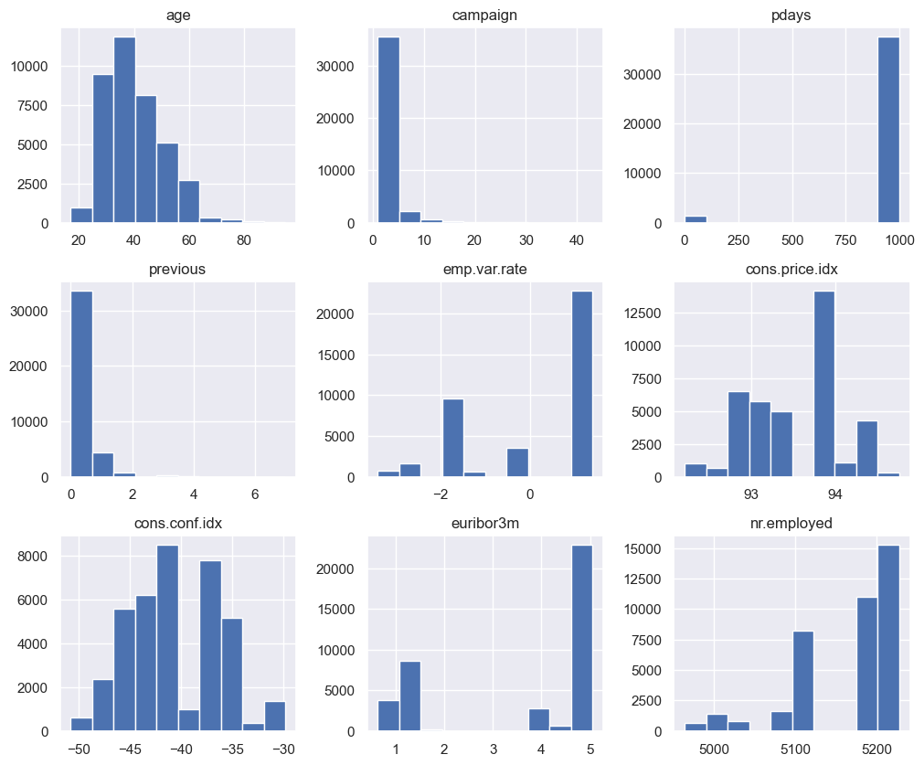

```python
banking_full_df[cont_cols].hist(figsize = (12,10))
```

Data skewness can be handled using Mathematical transformers such as

- Function Transformers (log transform, sqaure transform, sq root transform etc)
- Power Transofrmers (Box-Cox, Yeo-Johnson)
- Quantile transformer.

In our case with right skewed data, we will use Log Transforms. In this tranformation technique, we will use log of each and every value in the feature. So when we use logs of a certain distribution, we will use their exponents instead of the actual value. This makes the X scale exponentially grow in value and that is the reason why only Right Skewed data transforms to a more or less normal distribution.

```python
logarithm_transformer = FunctionTransformer(np.log1p, validate=True)

# apply the transformation to your data
columns = ['age', 'campaign', 'previous']
banking_full_df[columns] = logarithm_transformer.fit_transform(banking_full_df[columns])
```

```python
banking_full_df[['age', 'campaign', 'previous']].skew().sort_values(ascending = False)
```

```
previous    2.574763
campaign    1.306903
age         0.114371
dtype: float64
```

```python
columns = ['nr.employed']
exp_transformer = FunctionTransformer(lambda x:x**2, validate=True)
banking_full_df[columns] = exp_transformer.transform(banking_full_df[columns])
```

```python
banking_full_df[cont_cols].skew().sort_values(ascending = False)
```

```
previous          2.574763
campaign          1.306903
cons.conf.idx     0.137539
age               0.114371
cons.price.idx   -0.225919
emp.var.rate     -0.710975
euribor3m        -0.719124
nr.employed      -1.044699
pdays            -4.911280
dtype: float64
```

```
array([[<AxesSubplot:title={'center':'age'}>,
        <AxesSubplot:title={'center':'campaign'}>,
        <AxesSubplot:title={'center':'pdays'}>],
       [<AxesSubplot:title={'center':'previous'}>,
        <AxesSubplot:title={'center':'emp.var.rate'}>,
        <AxesSubplot:title={'center':'cons.price.idx'}>],
       [<AxesSubplot:title={'center':'cons.conf.idx'}>,
        <AxesSubplot:title={'center':'euribor3m'}>,
        <AxesSubplot:title={'center':'nr.employed'}>]], dtype=object)
```

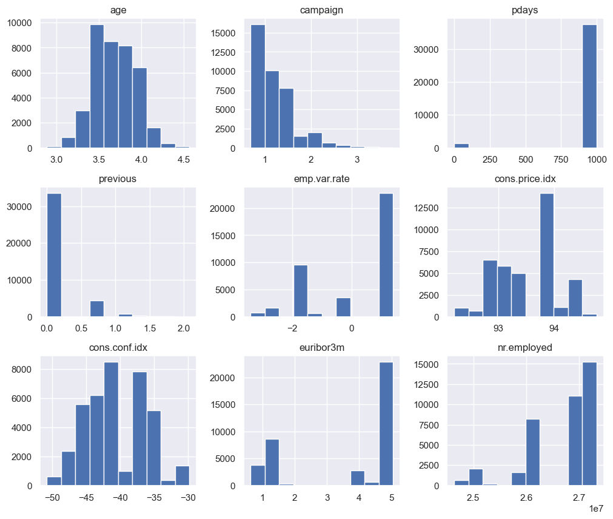

```python
banking_full_df[cont_cols].hist(figsize = (12,10))
```

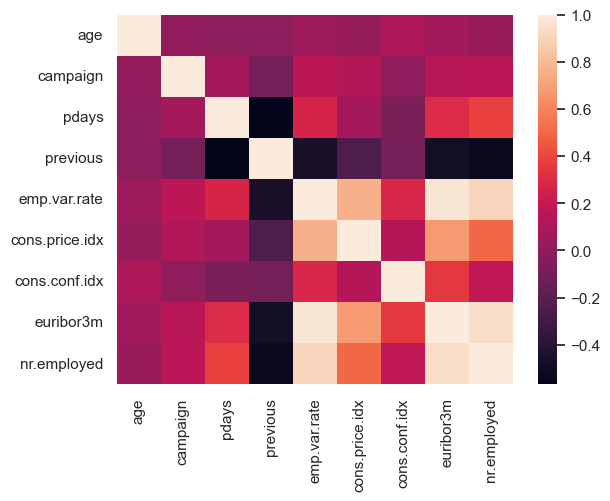

```python
df_feature_engg = banking_full_df[cont_cols]
sns.heatmap(df_feature_engg.corr())
```

###### nr.employed, euribor3m, emp.var.rate, cons.price.idx are dependent on each other

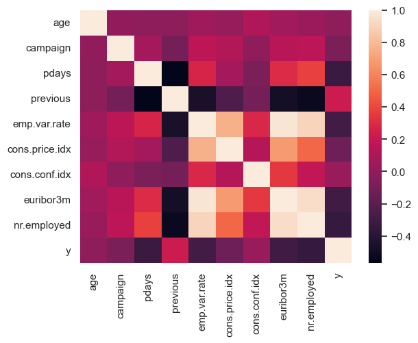

```python
df_feature_engg = banking_full_df[cont_cols]
df_feature_engg = df_feature_engg.join(banking_full_df['y'])
sns.heatmap(df_feature_engg.corr())
```

```python
# drop euribor3m, emp.var.rate, cons.price.idx
cols_to_drop = ["euribor3m", "emp.var.rate", "cons.price.idx"]
banking_full_df.drop(columns=cols_to_drop, inplace=True)
```

```python
X = banking_full_df.drop('y', axis=1)
y = banking_full_df['y']
```

```python
banking_full_df.describe()
```

|  | age | campaign | pdays | previous | cons.conf.idx | nr.employed | y | default_no | default_unknown | default_yes | job_admin. | job_blue-collar | job_entrepreneur | job_housemaid | job_management | job_retired | job_self-employed | job_services | job_student | job_technician | job_unemployed | job_unknown | day_of_week_fri | day_of_week_mon | day_of_week_thu | day_of_week_tue | day_of_week_wed | housing_no | housing_unknown | … |
| --- | --- | --- | --- | --- | --- | --- | --- | --- | --- | --- | --- | --- | --- | --- | --- | --- | --- | --- | --- | --- | --- | --- | --- | --- | --- | --- | --- | --- | --- | --- |
| count | 38967.000000 | 38967.000000 | 38967.000000 | 38967.000000 | 38967.000000 | 3.896700e+04 | 38967.000000 | 38967.000000 | 38967.000000 | 38967.000000 | 38967.000000 | 38967.000000 | 38967.000000 | 38967.000000 | 38967.000000 | 38967.000000 | 38967.000000 | 38967.000000 | 38967.000000 | 38967.000000 | 38967.000000 | 38967.000000 | 38967.000000 | 38967.000000 | 38967.000000 | 38967.000000 | 38967.000000 | 38967.000000 | 38967.000000 | … |
| mean | 3.684385 | 1.133970 | 962.332127 | 0.109136 | -40.651875 | 2.670968e+07 | 0.113455 | 0.788154 | 0.211769 | 0.000077 | 0.250263 | 0.226012 | 0.035825 | 0.026099 | 0.071317 | 0.040958 | 0.035312 | 0.097159 | 0.021249 | 0.162676 | 0.024944 | 0.008186 | 0.191598 | 0.208638 | 0.207432 | 0.195319 | 0.197013 | 0.453435 | 0.024816 | … |
| std | 0.246466 | 0.496563 | 187.258732 | 0.284625 | 4.440565 | 7.329947e+05 | 0.317152 | 0.408621 | 0.408567 | 0.008774 | 0.433170 | 0.418252 | 0.185856 | 0.159432 | 0.257357 | 0.198195 | 0.184569 | 0.296178 | 0.144214 | 0.369075 | 0.155957 | 0.090109 | 0.393563 | 0.406340 | 0.405473 | 0.396451 | 0.397747 | 0.497833 | 0.155566 | … |
| min | 2.890372 | 0.693147 | 0.000000 | 0.000000 | -50.800000 | 2.463732e+07 | 0.000000 | 0.000000 | 0.000000 | 0.000000 | 0.000000 | 0.000000 | 0.000000 | 0.000000 | 0.000000 | 0.000000 | 0.000000 | 0.000000 | 0.000000 | 0.000000 | 0.000000 | 0.000000 | 0.000000 | 0.000000 | 0.000000 | 0.000000 | 0.000000 | 0.000000 | 0.000000 | … |
| 25% | 3.496508 | 0.693147 | 999.000000 | 0.000000 | -42.700000 | 2.600082e+07 | 0.000000 | 1.000000 | 0.000000 | 0.000000 | 0.000000 | 0.000000 | 0.000000 | 0.000000 | 0.000000 | 0.000000 | 0.000000 | 0.000000 | 0.000000 | 0.000000 | 0.000000 | 0.000000 | 0.000000 | 0.000000 | 0.000000 | 0.000000 | 0.000000 | 0.000000 | 0.000000 | … |
| 50% | 3.663562 | 1.098612 | 999.000000 | 0.000000 | -41.800000 | 2.694648e+07 | 0.000000 | 1.000000 | 0.000000 | 0.000000 | 0.000000 | 0.000000 | 0.000000 | 0.000000 | 0.000000 | 0.000000 | 0.000000 | 0.000000 | 0.000000 | 0.000000 | 0.000000 | 0.000000 | 0.000000 | 0.000000 | 0.000000 | 0.000000 | 0.000000 | 0.000000 | 0.000000 | … |
| 75% | 3.871201 | 1.386294 | 999.000000 | 0.000000 | -36.400000 | 2.733303e+07 | 0.000000 | 1.000000 | 0.000000 | 0.000000 | 1.000000 | 0.000000 | 0.000000 | 0.000000 | 0.000000 | 0.000000 | 0.000000 | 0.000000 | 0.000000 | 0.000000 | 0.000000 | 0.000000 | 0.000000 | 0.000000 | 0.000000 | 0.000000 | 0.000000 | 1.000000 | 0.000000 | … |
| max | 4.564348 | 3.784190 | 999.000000 | 2.079442 | -29.800000 | 2.733303e+07 | 1.000000 | 1.000000 | 1.000000 | 1.000000 | 1.000000 | 1.000000 | 1.000000 | 1.000000 | 1.000000 | 1.000000 | 1.000000 | 1.000000 | 1.000000 | 1.000000 | 1.000000 | 1.000000 | 1.000000 | 1.000000 | 1.000000 | 1.000000 | 1.000000 | 1.000000 | 1.000000 | … |

```python
transform_cols = ["campaign", "pdays", "previous", "cons.conf.idx", "nr.employed"]
banking_full_df[transform_cols] = StandardScaler().fit_transform(banking_full_df[transform_cols])
```

```python
banking_full_df.describe().T
```

|  | count | mean | std | min | 25% | 50% | 75% | max |
| --- | --- | --- | --- | --- | --- | --- | --- | --- |
| age | 38967.0 | 3.684385e+00 | 0.246466 | 2.890372 | 3.496508 | 3.663562 | 3.871201 | 4.564348 |
| campaign | 38967.0 | 2.684115e-16 | 1.000013 | -0.887760 | -0.887760 | -0.071207 | 0.508148 | 5.337196 |
| pdays | 38967.0 | -1.867210e-16 | 1.000013 | -5.139117 | 0.195816 | 0.195816 | 0.195816 | 0.195816 |
| previous | 38967.0 | 9.336051e-17 | 1.000013 | -0.383443 | -0.383443 | -0.383443 | -0.383443 | 6.922557 |
| cons.conf.idx | 38967.0 | 3.092567e-16 | 1.000013 | -2.285353 | -0.461237 | -0.258557 | 0.957520 | 2.443836 |
| nr.employed | 38967.0 | -6.208474e-15 | 1.000013 | -2.827284 | -0.967088 | 0.323060 | 0.850423 | 0.850423 |
| y | 38967.0 | 1.134550e-01 | 0.317152 | 0.000000 | 0.000000 | 0.000000 | 0.000000 | 1.000000 |
| default_no | 38967.0 | 7.881541e-01 | 0.408621 | 0.000000 | 1.000000 | 1.000000 | 1.000000 | 1.000000 |
| default_unknown | 38967.0 | 2.117689e-01 | 0.408567 | 0.000000 | 0.000000 | 0.000000 | 0.000000 | 1.000000 |
| default_yes | 38967.0 | 7.698822e-05 | 0.008774 | 0.000000 | 0.000000 | 0.000000 | 0.000000 | 1.000000 |
| job_admin. | 38967.0 | 2.502630e-01 | 0.433170 | 0.000000 | 0.000000 | 0.000000 | 1.000000 | 1.000000 |
| job_blue-collar | 38967.0 | 2.260118e-01 | 0.418252 | 0.000000 | 0.000000 | 0.000000 | 0.000000 | 1.000000 |
| job_entrepreneur | 38967.0 | 3.582519e-02 | 0.185856 | 0.000000 | 0.000000 | 0.000000 | 0.000000 | 1.000000 |
| job_housemaid | 38967.0 | 2.609901e-02 | 0.159432 | 0.000000 | 0.000000 | 0.000000 | 0.000000 | 1.000000 |
| job_management | 38967.0 | 7.131676e-02 | 0.257357 | 0.000000 | 0.000000 | 0.000000 | 0.000000 | 1.000000 |
| job_retired | 38967.0 | 4.095773e-02 | 0.198195 | 0.000000 | 0.000000 | 0.000000 | 0.000000 | 1.000000 |
| job_self-employed | 38967.0 | 3.531193e-02 | 0.184569 | 0.000000 | 0.000000 | 0.000000 | 0.000000 | 1.000000 |
| job_services | 38967.0 | 9.715913e-02 | 0.296178 | 0.000000 | 0.000000 | 0.000000 | 0.000000 | 1.000000 |
| job_student | 38967.0 | 2.124875e-02 | 0.144214 | 0.000000 | 0.000000 | 0.000000 | 0.000000 | 1.000000 |
| job_technician | 38967.0 | 1.626761e-01 | 0.369075 | 0.000000 | 0.000000 | 0.000000 | 0.000000 | 1.000000 |
| job_unemployed | 38967.0 | 2.494418e-02 | 0.155957 | 0.000000 | 0.000000 | 0.000000 | 0.000000 | 1.000000 |
| job_unknown | 38967.0 | 8.186414e-03 | 0.090109 | 0.000000 | 0.000000 | 0.000000 | 0.000000 | 1.000000 |
| day_of_week_fri | 38967.0 | 1.915980e-01 | 0.393563 | 0.000000 | 0.000000 | 0.000000 | 0.000000 | 1.000000 |
| day_of_week_mon | 38967.0 | 2.086381e-01 | 0.406340 | 0.000000 | 0.000000 | 0.000000 | 0.000000 | 1.000000 |
| day_of_week_thu | 38967.0 | 2.074319e-01 | 0.405473 | 0.000000 | 0.000000 | 0.000000 | 0.000000 | 1.000000 |
| day_of_week_tue | 38967.0 | 1.953191e-01 | 0.396451 | 0.000000 | 0.000000 | 0.000000 | 0.000000 | 1.000000 |
| day_of_week_wed | 38967.0 | 1.970129e-01 | 0.397747 | 0.000000 | 0.000000 | 0.000000 | 0.000000 | 1.000000 |
| housing_no | 38967.0 | 4.534350e-01 | 0.497833 | 0.000000 | 0.000000 | 0.000000 | 1.000000 | 1.000000 |
| housing_unknown | 38967.0 | 2.481587e-02 | 0.155566 | 0.000000 | 0.000000 | 0.000000 | 0.000000 | 1.000000 |
| housing_yes | 38967.0 | 5.217492e-01 | 0.499533 | 0.000000 | 0.000000 | 1.000000 | 1.000000 | 1.000000 |
| poutcome_failure | 38967.0 | 1.044730e-01 | 0.305877 | 0.000000 | 0.000000 | 0.000000 | 0.000000 | 1.000000 |
| poutcome_nonexistent | 38967.0 | 8.620371e-01 | 0.344865 | 0.000000 | 1.000000 | 1.000000 | 1.000000 | 1.000000 |
| poutcome_success | 38967.0 | 3.348988e-02 | 0.179914 | 0.000000 | 0.000000 | 0.000000 | 0.000000 | 1.000000 |
| loan_no | 38967.0 | 8.180768e-01 | 0.385786 | 0.000000 | 1.000000 | 1.000000 | 1.000000 | 1.000000 |
| loan_unknown | 38967.0 | 2.481587e-02 | 0.155566 | 0.000000 | 0.000000 | 0.000000 | 0.000000 | 1.000000 |
| loan_yes | 38967.0 | 1.571073e-01 | 0.363907 | 0.000000 | 0.000000 | 0.000000 | 0.000000 | 1.000000 |
| education_basic.4y | 38967.0 | 1.009059e-01 | 0.301208 | 0.000000 | 0.000000 | 0.000000 | 0.000000 | 1.000000 |
| education_basic.6y | 38967.0 | 5.656068e-02 | 0.231004 | 0.000000 | 0.000000 | 0.000000 | 0.000000 | 1.000000 |
| education_basic.9y | 38967.0 | 1.475351e-01 | 0.354643 | 0.000000 | 0.000000 | 0.000000 | 0.000000 | 1.000000 |
| education_high.school | 38967.0 | 2.317859e-01 | 0.421978 | 0.000000 | 0.000000 | 0.000000 | 0.000000 | 1.000000 |
| education_illiterate | 38967.0 | 4.619293e-04 | 0.021488 | 0.000000 | 0.000000 | 0.000000 | 0.000000 | 1.000000 |
| education_professional.course | 38967.0 | 1.273385e-01 | 0.333356 | 0.000000 | 0.000000 | 0.000000 | 0.000000 | 1.000000 |
| education_university.degree | 38967.0 | 2.926322e-01 | 0.454977 | 0.000000 | 0.000000 | 0.000000 | 1.000000 | 1.000000 |
| education_unknown | 38967.0 | 4.277979e-02 | 0.202363 | 0.000000 | 0.000000 | 0.000000 | 0.000000 | 1.000000 |
| month_apr | 38967.0 | 6.505505e-02 | 0.246626 | 0.000000 | 0.000000 | 0.000000 | 0.000000 | 1.000000 |
| month_aug | 38967.0 | 1.467652e-01 | 0.353876 | 0.000000 | 0.000000 | 0.000000 | 0.000000 | 1.000000 |
| month_dec | 38967.0 | 4.644956e-03 | 0.067996 | 0.000000 | 0.000000 | 0.000000 | 0.000000 | 1.000000 |
| month_jul | 38967.0 | 1.718890e-01 | 0.377289 | 0.000000 | 0.000000 | 0.000000 | 0.000000 | 1.000000 |
| month_jun | 38967.0 | 1.346011e-01 | 0.341301 | 0.000000 | 0.000000 | 0.000000 | 0.000000 | 1.000000 |
| month_mar | 38967.0 | 1.360125e-02 | 0.115830 | 0.000000 | 0.000000 | 0.000000 | 0.000000 | 1.000000 |
| month_may | 38967.0 | 3.416737e-01 | 0.474277 | 0.000000 | 0.000000 | 0.000000 | 1.000000 | 1.000000 |
| month_nov | 38967.0 | 1.003413e-01 | 0.300458 | 0.000000 | 0.000000 | 0.000000 | 0.000000 | 1.000000 |
| month_oct | 38967.0 | 6.954603e-03 | 0.083105 | 0.000000 | 0.000000 | 0.000000 | 0.000000 | 1.000000 |
| month_sep | 38967.0 | 1.447379e-02 | 0.119435 | 0.000000 | 0.000000 | 0.000000 | 0.000000 | 1.000000 |
| marital_divorced | 38967.0 | 1.135320e-01 | 0.317246 | 0.000000 | 0.000000 | 0.000000 | 0.000000 | 1.000000 |
| marital_married | 38967.0 | 6.058460e-01 | 0.488674 | 0.000000 | 0.000000 | 1.000000 | 1.000000 | 1.000000 |
| marital_single | 38967.0 | 2.786460e-01 | 0.448339 | 0.000000 | 0.000000 | 0.000000 | 1.000000 | 1.000000 |
| marital_unknown | 38967.0 | 1.976031e-03 | 0.044409 | 0.000000 | 0.000000 | 0.000000 | 0.000000 | 1.000000 |

```
array([[<AxesSubplot:title={'center':'campaign'}>,
        <AxesSubplot:title={'center':'pdays'}>],
       [<AxesSubplot:title={'center':'previous'}>,
        <AxesSubplot:title={'center':'cons.conf.idx'}>],
       [<AxesSubplot:title={'center':'nr.employed'}>, <AxesSubplot:>]],
      dtype=object)
```

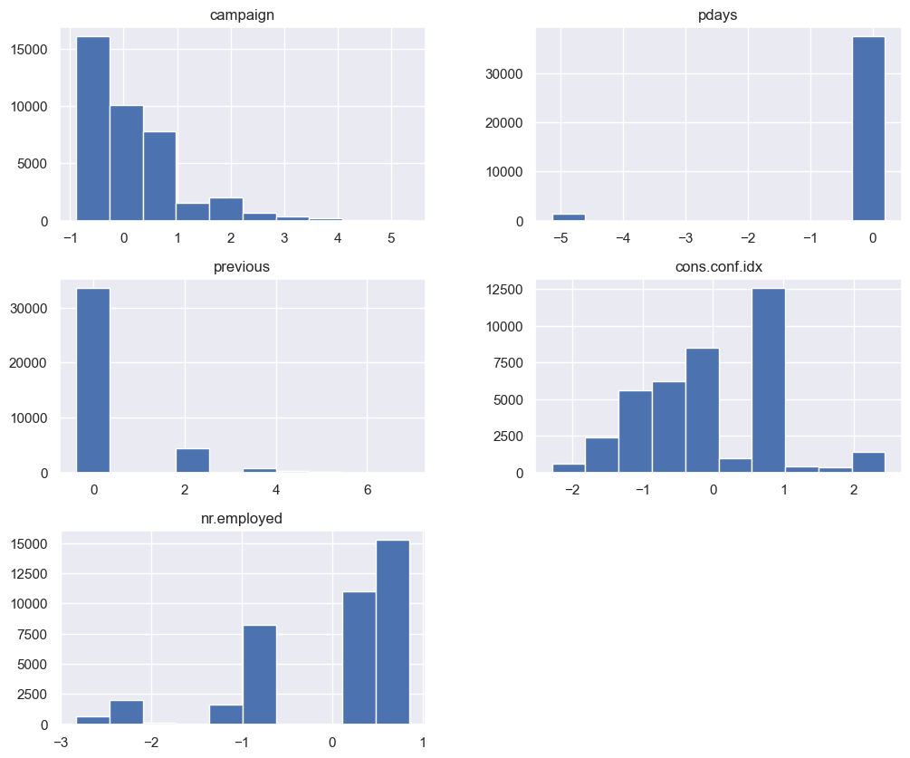

```python
banking_full_df[transform_cols].hist(figsize = (12,10))
```

### Problem 5: Engineering Features

Now that you understand your business objective, we will build a basic model to get started. Before we can do this, we must work to encode the data. Using just the bank information features (columns 1 - 7), prepare the features and target column for modeling with appropriate encoding and transformations.

```python
X = banking_full_df.drop("y", axis=1)
y = banking_full_df["y"]
```

```python
X_train, X_test, y_train, y_test = train_test_split(X, y, test_size=0.3, random_state=42)
print(f"Shape of X_train: {X_train.shape}")
print(f"Shape of y_train: {X_test.shape}")
```

```
Shape of X_train: (27276, 57)
Shape of y_train: (11691, 57)
```

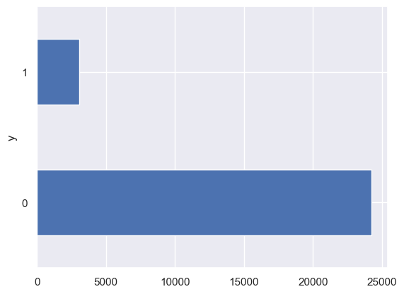

```python
# understand the distribution of yes and no in the training set
y_train.value_counts().plot(kind='barh')
```

### SMOTE

Since there is imbalance in the datasets, let's use SMOTE technique to balance the datasets. SMOTE use the oversampling method to balance the imbalanced datasets.

Let's perform oversampling only on the training sets and not on the test sets

```python
smt = SMOTE(random_state=42)
X_train, y_train = smt.fit_resample(X_train, y_train)
```

```python
print(f"Shape of training sets after oversampling {X_train.shape}")
print(f"Shape of training target sets after oversampling {y_train.shape}")
```

```
Shape of training sets after oversampling (48436, 57)
Shape of training target sets after oversampling (48436,)
```

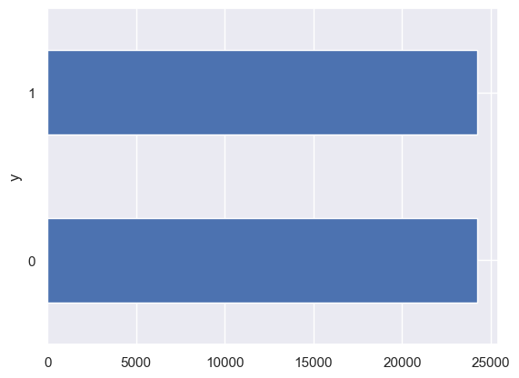

```python
# understand the distribution of yes and no in the training set after oversampling
y_train.value_counts().plot(kind='barh')
```

### Problem 8: A Simple Model

Use Logistic Regression to build a basic model on your data.

```python
model = LogisticRegression().fit(X_train, y_train)
```

```python
y_pred = model.predict(X_test)
```

```python
# Let's get the accuracy of the model
print(classification_report(y_test, y_pred))
```

```
              precision    recall  f1-score   support

           0       0.94      0.84      0.89     10328
           1       0.35      0.63      0.45      1363

    accuracy                           0.82     11691
   macro avg       0.65      0.74      0.67     11691
weighted avg       0.88      0.82      0.84     11691
```

```python
clf = SVC()
clf.fit(X_train, y_train)
#Predict the response for test dataset
y_pred = clf.predict(X_test)
```

```python
print(f"Training Score: {clf.score(X_train, y_train)}")
```

```
Training Score: 0.8254604013543645
```

```python
print (f"Accuracy Score: {accuracy_score(y_test, y_pred)}")
print (f"Classification Report: {classification_report(y_test, y_pred)}")
```

```
Accuracy Score: 0.857069540672312
Classification Report:               precision    recall  f1-score   support

           0       0.94      0.90      0.92     10328
           1       0.41      0.54      0.47      1363

    accuracy                           0.86     11691
   macro avg       0.67      0.72      0.69     11691
weighted avg       0.88      0.86      0.86     11691
```

```python
C_range = np.logspace(-1, 1, 3)
print(f"List of values for C are {C_range}")

gamma_range = np.logspace(-1, 1, 3)
print(f"List of gamma range are {gamma_range}")

param_grid = {
    "C": C_range,
    "kernel": ["rbf"],
    "gamma": gamma_range.tolist()
}
print (f"Param Grid {param_grid}")

# https://scikit-learn.org/stable/modules/model_evaluation.html#the-scoring-parameter-defining-model-evaluation-rules
scoring = ["f1"]

kfold = StratifiedKFold(n_splits=3, shuffle=True, random_state=0)

svc = SVC()
svc_params = svc.get_params()
params_df = pd.DataFrame(svc_params, index=[0])
params_df.T
```

```
List of values for C are [ 0.1  1.  10. ]
List of gamma range are [ 0.1  1.  10. ]
Param Grid {'C': array([ 0.1,  1. , 10. ]), 'kernel': ['rbf'], 'gamma': [0.1, 1.0, 10.0]}
```

|  | 0 |
| --- | --- |
| C | 1.0 |
| break_ties | False |
| cache_size | 200 |
| class_weight | None |
| coef0 | 0.0 |
| decision_function_shape | ovr |
| degree | 3 |
| gamma | scale |
| kernel | rbf |
| max_iter | -1 |
| probability | False |
| random_state | None |
| shrinking | True |
| tol | 0.001 |
| verbose | False |

```python
grid_search = GridSearchCV(
    estimator=svc,
    param_grid=param_grid,
    n_jobs = -1,
    cv = kfold,
    verbose=0,
    scoring=scoring,
    refit = 'f1'
)
```

```python
grid_result = grid_search.fit(X_train, y_train)
```

```python
grid_result
```

```
GridSearchCV(cv=StratifiedKFold(n_splits=3, random_state=0, shuffle=True),
             estimator=SVC(), n_jobs=-1,
             param_grid={'C': array([ 0.1,  1. , 10. ]),
                         'gamma': [0.1, 1.0, 10.0], 'kernel': ['rbf']},
             refit='f1', scoring=['f1'])
```

```python
grid_result.best_score_
```

```
0.9493763537231902
```

```python
grid_result.best_params_
```

```
{'C': 10.0, 'gamma': 1.0, 'kernel': 'rbf'}
```

```python
svc_model = SVC(kernel='rbf',  gamma=1, C=10)
svc_model.fit(X_train, y_train)
y_pred_1 = svc_model.predict(X_test)
```

```python
print(f"Training Score: {svc_model.score(X_train, y_train)}")
```

```
Training Score: 0.9838549838962755
```

```python
print("Classification Report:", classification_report(y_test, y_pred_1))
```

```
Classification Report:               precision    recall  f1-score   support

           0       0.89      0.94      0.91     10328
           1       0.15      0.07      0.10      1363

    accuracy                           0.84     11691
   macro avg       0.52      0.51      0.51     11691
weighted avg       0.80      0.84      0.82     11691
```

```python
from sklearn.metrics import accuracy_score, f1_score, precision_score, recall_score
print (f"Accuracy Score: {accuracy_score(y_test, y_pred_1)}")
print (f"F1 score: {f1_score(y_test, y_pred_1)}")
print (f"Precision score: {precision_score(y_test, y_pred_1)}")
print (f"Recall score: {recall_score(y_test, y_pred_1)}")
```

```
Accuracy Score: 0.8409032589171157
F1 score: 0.09883720930232559
Precision score: 0.14550641940085593
Recall score: 0.0748349229640499
```

```python
svc_model_2 = SVC(kernel='rbf',  gamma=0.001, C=10)
svc_model_2.fit(X_train, y_train)
y_pred_2 = svc_model.predict(X_test)

print (f"F1 score: {f1_score(y_test, y_pred_2)}")
print (f"Precision score: {precision_score(y_test, y_pred_2)}")
print (f"Recall score: {recall_score(y_test, y_pred_2)}")
```

```
F1 score: 0.09883720930232559
Precision score: 0.14550641940085593
Recall score: 0.0748349229640499
```

```python
svc_model_3 = SVC(kernel='rbf',  gamma=0.001, C=100)
svc_model_3.fit(X_train, y_train)
y_pred_3 = svc_model.predict(X_test)

print (f"Accuracy Score: {accuracy_score(y_test, y_pred_3)}")
print (f"F1 score: {f1_score(y_test, y_pred_3)}")
print (f"Precision score: {precision_score(y_test, y_pred_3)}")
print (f"Recall score: {recall_score(y_test, y_pred_3)}")
```

```
Accuracy Score: 0.8409032589171157
F1 score: 0.09883720930232559
Precision score: 0.14550641940085593
Recall score: 0.0748349229640499
```

```python
print(f"Training Score of svc_model_3: {svc_model_3.score(X_train, y_train)}")
```

```
Training Score of svc_model_3: 0.7388925592534479
```